# Lab 2 - Avocados

Author

Kelly Ohata

**1. DESCRIPTION:** The dataset contains weekly retail scan data for avocado sales in the United States from 2015 to 2020, including information on average prices, total sales volume, avocado sizes, bag types, product type (conventional or organic), and geographic regions ranging from metro areas to the national level.

**2. CLEANING:**

```python
import numpy as np
import plotnine as p9
import pandas as pd
from plotnine import *

# Import avocado dataset
df = pd.read_csv("/Users/kellyohata/Documents/MSBA/GSB-544/Week 2/Lab 2/avocado-updated-2020.csv")

# Inspect data structure (important for verifying import)
df.info()

# Drop missing and duplicate rows
df_clean = df.dropna().drop_duplicates()

# Convert data types
df_clean['date'] = pd.to_datetime(df_clean['date'])
df_clean['type'] = df_clean['type'].astype('category')
df_clean['geography'] = df_clean['geography'].astype('category')

# Rename confusing numeric columns
df_clean = df_clean.rename(columns={
    '4046': 'Small_Avocados',
    '4225': 'Large_Avocados',
    '4770': 'XL_Avocados'
})

# Clean and classify all geography levels properly

# Convert to string in case it's categorical
df_clean['geography'] = df_clean['geography'].astype(str)

# Assign top-level classifications
region_map = {
    # National and regions
    'Total U.S.': 'National',
    'West': 'Region',
    'South Central': 'Region',
    'Northeast': 'Region',
    'Southeast': 'Region',
    'Great Lakes': 'Region',
    'Midsouth': 'Region',
    'Plains': 'Region',
    # State
    'California': 'State',
    # Metro (listed explicitly in dataset)
    'Albany': 'Metro',
    'Atlanta': 'Metro',
    'Baltimore/Washington': 'Metro',
    'Boise': 'Metro',
    'Boston': 'Metro',
    'Buffalo/Rochester': 'Metro',
    'Charlotte': 'Metro',
    'Chicago': 'Metro',
    'Cincinnati/Dayton': 'Metro',
    'Columbus': 'Metro',
    'Dallas/Ft. Worth': 'Metro',
    'Denver': 'Metro',
    'Detroit': 'Metro',
    'Grand Rapids': 'Metro',
    'Harrisburg/Scranton': 'Metro',
    'Hartford/Springfield': 'Metro',
    'Houston': 'Metro',
    'Indianapolis': 'Metro',
    'Jacksonville': 'Metro',
    'Las Vegas': 'Metro',
    'Los Angeles': 'Metro',
    'Louisville': 'Metro',
    'Miami/Ft. Lauderdale': 'Metro',
    'Nashville': 'Metro',
    'New Orleans/Mobile': 'Metro',
    'New York': 'Metro',
    'Northern New England': 'Metro',
    'Orlando': 'Metro',
    'Philadelphia': 'Metro',
    'Phoenix/Tucson': 'Metro',
    'Pittsburgh': 'Metro',
    'Portland': 'Metro',
    'Raleigh/Greensboro': 'Metro',
    'Richmond/Norfolk': 'Metro',
    'Roanoke': 'Metro',
    'Sacramento': 'Metro',
    'San Diego': 'Metro',
    'San Francisco': 'Metro',
    'Seattle': 'Metro',
    'South Carolina': 'Metro',
    'Spokane': 'Metro',
    'St. Louis': 'Metro',
    'Syracuse': 'Metro'
}

# Apply mapping
df_clean['region_type'] = df_clean['geography'].replace(region_map)

# Double-check that all are assigned
df_clean['region_type'] = df_clean['region_type'].fillna('Metro')

# Verify
df_clean['region_type'].value_counts(dropna=False)
# Final cleanup of any remaining unmatched regions

# Add missing ones to the correct category
df_clean['region_type'] = df_clean['region_type'].replace({
    'Tampa': 'Metro',
    'West Tex/New Mexico': 'Region'
})

# Confirm every geography is now assigned correctly
df_clean['region_type'] = pd.Categorical(
    df_clean['region_type'],
    categories=['National', 'Region', 'State', 'Metro'],
    ordered=True
)

print(df_clean['region_type'].value_counts(dropna=False))
```

```
<class 'pandas.core.frame.DataFrame'>
RangeIndex: 33045 entries, 0 to 33044
Data columns (total 13 columns):
 #   Column         Non-Null Count  Dtype
---  ------         --------------  -----
 0   date           33045 non-null  object
 1   average_price  33045 non-null  float64
 2   total_volume   33045 non-null  float64
 3   4046           33045 non-null  float64
 4   4225           33045 non-null  float64
 5   4770           33045 non-null  float64
 6   total_bags     33045 non-null  float64
 7   small_bags     33045 non-null  float64
 8   large_bags     33045 non-null  float64
 9   xlarge_bags    33045 non-null  float64
 10  type           33045 non-null  object
 11  year           33045 non-null  int64
 12  geography      33045 non-null  object
dtypes: float64(9), int64(1), object(3)
memory usage: 3.3+ MB
region_type
Metro       26928
Region       4893
National      612
State         612
Name: count, dtype: int64
```

**3. Which major geographical region sold the most total organic, small Hass avocados in 2017?**

```python
# Filter for organic avocados in 2017
df_2017_org = df_clean.query("type == 'organic' and year == 2017")

# Summarize total small Hass avocados sold by major region (Region)
region_sales_2017 = (
    df_2017_org
    .query("region_type == 'Region'")
    .groupby('geography')
    .agg(total_small_hass=('Small_Avocados', 'sum'))
    .reset_index()
    .sort_values('total_small_hass', ascending=False)
)

# Display the region with the highest total sales
region_sales_2017.head(1)
```

|  | geography | total_small_hass |
| --- | --- | --- |
| 6 | West | 1870206.29 |

**4. Split the date variable into month, day, and year variables. In which month is the highest average volume of avocado sales?**

```python
# Split the date column into month, day, and year
df_clean['month'] = df_clean['date'].dt.month
df_clean['day'] = df_clean['date'].dt.day
df_clean['year'] = df_clean['date'].dt.year

# Calculate the average total volume of avocado sales by month
monthly_volume = (
    df_clean
    .groupby('month')
    .agg(avg_total_volume=('total_volume', 'mean'))
    .reset_index()
    .sort_values('avg_total_volume', ascending=False)
)

monthly_volume.head(1)
```

|  | month | avg_total_volume |
| --- | --- | --- |
| 4 | 5 | 1.123632e+06 |

**5. Which metro area geographical regions sold the most total avocados? Plot side-by-side box-plots of the total volume for only the five metro geographical regions with the highest averages for the total_volume variable.**

- Los Angeles sold the most total avocados

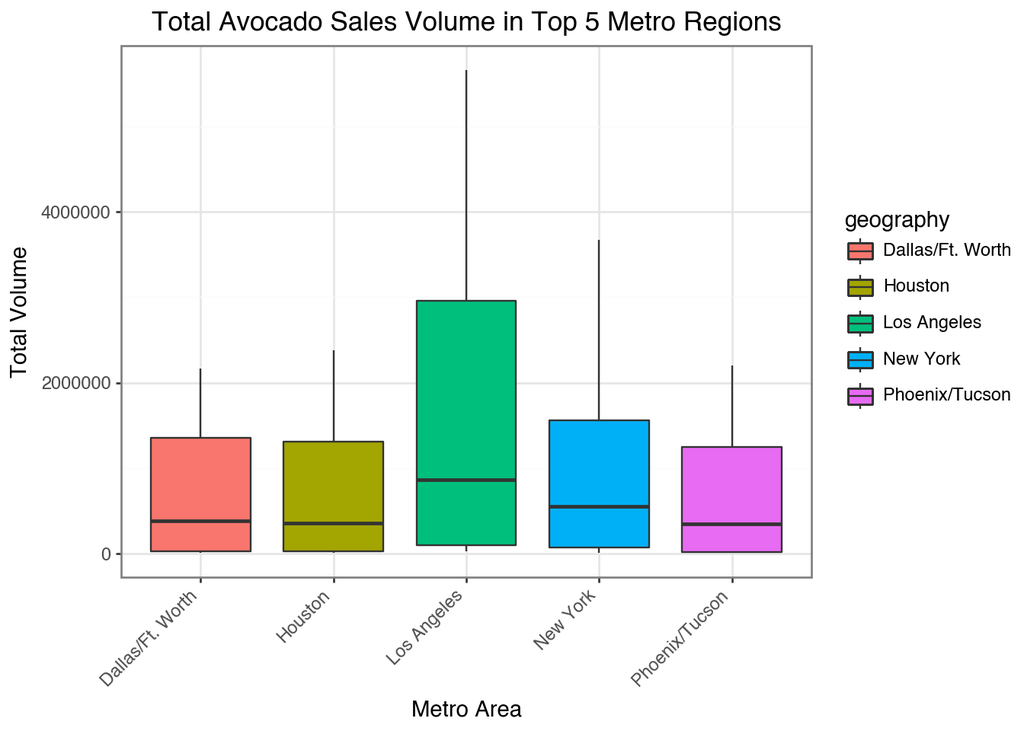

```python
# Filter only metro regions
df_metro = df_clean.query("region_type == 'Metro'")

# Summarize average total volume by metro geography
top5_metros = (
    df_metro
    .groupby('geography')
    .agg(avg_total_volume=('total_volume', 'mean'))
    .reset_index()
    .sort_values('avg_total_volume', ascending=False)
    .head(5)
)

# Extract the five metro names
top5_names = top5_metros['geography'].tolist()

# Filter dataset to include only those top 5 metros
df_top5 = df_metro.query("geography in @top5_names")

# Boxplots
(
    p9.ggplot(df_top5, aes(x='geography', y='total_volume', fill='geography'))
    + geom_boxplot()
    + labs(
        title='Total Avocado Sales Volume in Top 5 Metro Regions',
        x='Metro Area',
        y='Total Volume'
    )
    + theme_bw()
    + theme(axis_text_x=element_text(rotation=45, hjust=1))
)
```

**6. From your cleaned data set, create a data set with only these California regions and answer the following questions about these California regions only.**

```python
# --- Step 6: California-only subset and total avocado sales ---

# Define the four California metro regions
california_regions = ["Los Angeles", "San Diego", "Sacramento", "San Francisco"]

# Create a dataset containing only these regions
df_ca = df_clean.query("geography in @california_regions")

# Summarize total avocado sales volume by California metro
ca_total_sales = (
    df_ca
    .groupby('geography')
    .agg(total_avocados_sold=('total_volume', 'sum'))
    .reset_index()
    .sort_values('total_avocados_sold', ascending=False)
)

print("Total Avocado Sales by California Metro Region:")
display(ca_total_sales)
```

```
Total Avocado Sales by California Metro Region:
```

|  | geography | total_avocados_sold |
| --- | --- | --- |
| 0 | Los Angeles | 9.593505e+08 |
| 3 | San Francisco | 2.742169e+08 |
| 2 | San Diego | 1.737644e+08 |
| 1 | Sacramento | 1.492713e+08 |

**7. In which California regions is the price of organic versus conventional avocados most different? Support your answer with a few summary statistics AND a visualization.**

- San Francisco shows the largest average price difference between organic and conventional avocados, with organic prices about $0.72 higher on average.

| type | geography | conventional | organic | price_difference |
| --- | --- | --- | --- | --- |
| 3 | San Francisco | 1.400490 | 2.119444 | 0.718954 |
| 2 | San Diego | 1.113856 | 1.798366 | 0.684510 |
| 1 | Sacramento | 1.295359 | 1.873856 | 0.578497 |
| 0 | Los Angeles | 1.047124 | 1.574902 | 0.527778 |

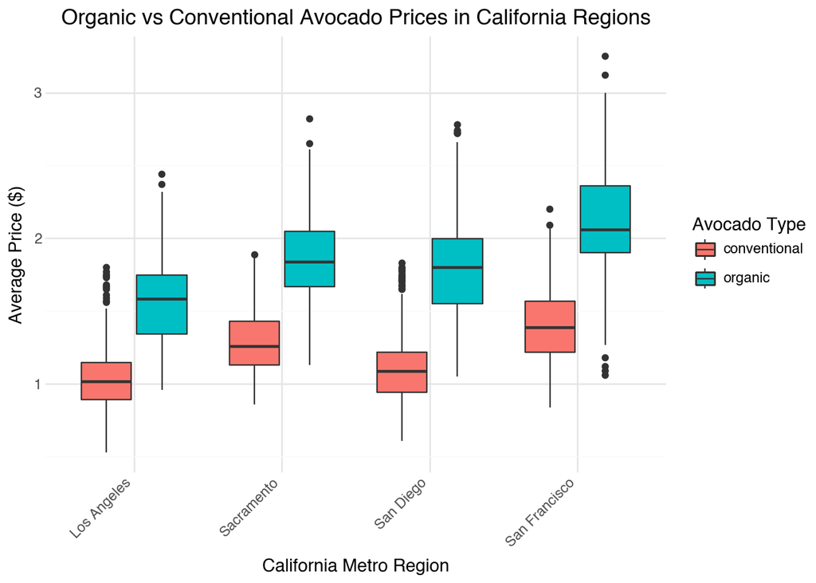

```python
# Average price by region and type
ca_price_summary = (
    df_ca
    .groupby(['geography', 'type'])
    .agg(avg_price=('average_price', 'mean'))
    .reset_index()
)

ca_price_pivot = ca_price_summary.pivot(index='geography', columns='type', values='avg_price').reset_index()

# absolute difference in average price between the two types
ca_price_pivot['price_difference'] = abs(ca_price_pivot['organic'] - ca_price_pivot['conventional'])

# Sort by the largest difference
ca_price_pivot = ca_price_pivot.sort_values('price_difference', ascending=False)

display(ca_price_pivot)

# Identify region with biggest price difference
top_diff_region = ca_price_pivot.iloc[0]

# Boxplot
(
    ggplot(df_ca, aes(x='geography', y='average_price', fill='type'))
    + geom_boxplot()
    + labs(
        title='Organic vs Conventional Avocado Prices in California Regions',
        x='California Metro Region',
        y='Average Price ($)',
        fill='Avocado Type'
    )
    + theme_minimal()
    + theme(axis_text_x=element_text(rotation=45, hjust=1))
)
```

**8. The following plot shows, for all four California regions, the proportion of the average Hass avocado sales that are small, large, or extra large; conventional vs. organic. Recreate the plot; you do not have to replicate the exact finishing touches - e.g., color, theme - but your plot should resemble the content of this plot.**

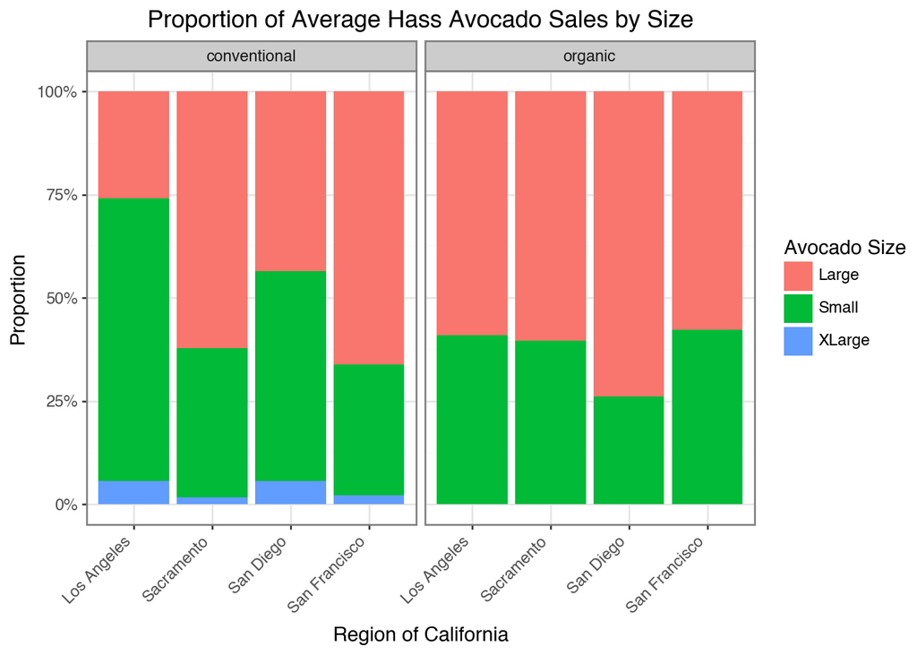

```python
# Summarize mean sales by region and type
ca_size_summary = (
    df_ca
    .groupby(['geography', 'type'])
    .agg(
        avg_small=('Small_Avocados', 'mean'),
        avg_large=('Large_Avocados', 'mean'),
        avg_xlarge=('XL_Avocados', 'mean')
    )
    .reset_index()
)

# Compute proportions (each row sums to 1)
ca_size_summary['total'] = ca_size_summary[['avg_small', 'avg_large', 'avg_xlarge']].sum(axis=1)
ca_size_summary['prop_small'] = ca_size_summary['avg_small'] / ca_size_summary['total']
ca_size_summary['prop_large'] = ca_size_summary['avg_large'] / ca_size_summary['total']
ca_size_summary['prop_xlarge'] = ca_size_summary['avg_xlarge'] / ca_size_summary['total']

# Reshape to long format
ca_size_long = pd.melt(
    ca_size_summary,
    id_vars=['geography', 'type'],
    value_vars=['prop_small', 'prop_large', 'prop_xlarge'],
    var_name='size',
    value_name='proportion'
)

# Clean up labels
ca_size_long['size'] = ca_size_long['size'].replace({
    'prop_small': 'Small',
    'prop_large': 'Large',
    'prop_xlarge': 'XLarge'
})

# Graph
(
    p9.ggplot(ca_size_long, aes(x='geography', y='proportion', fill='size'))
    + geom_bar(stat='identity', position='stack')
    + facet_wrap('~type')
    + labs(
        title='Proportion of Average Hass Avocado Sales by Size',
        x='Region of California',
        y='Proportion',
        fill='Avocado Size'
    )
    # Define breaks and labels numerically (no iteration)
    + scale_y_continuous(
        breaks=np.array([0.0, 0.25, 0.5, 0.75, 1.0]),
        labels=np.array(["0%", "25%", "50%", "75%", "100%"])
    )
    + theme_bw()
    + theme(axis_text_x=element_text(rotation=45, hjust=1))
)
```

**9. Using Outside Data**

- Based on the joined dataset, there is a mild positive relationship between California home prices and average avocado prices, indicating that while both have risen over time due to broader economic trends, increasing avocado prices are not a driving factor behind higher housing costs or affordability issues.

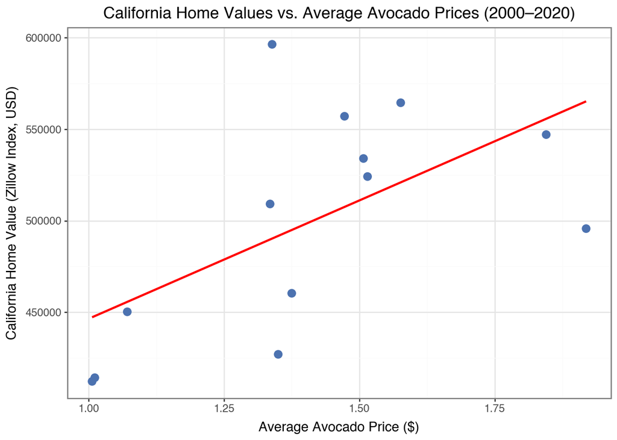

```python
zhvi = pd.read_csv("/Users/kellyohata/Documents/MSBA/GSB-544/Week 2/Lab 2/ZHVI.csv")
# Convert date and keep only California
zhvi = zhvi.rename(columns={'Unnamed: 0': 'date'})
zhvi['date'] = pd.to_datetime(zhvi['date'])
zhvi_ca = zhvi[['date', 'California']].copy()
zhvi_ca = zhvi_ca.rename(columns={'California': 'home_value'})

# Use average price across all California metros to align with state home value
df_ca_mean = (
    df_ca.groupby('date')
    .agg(avg_avocado_price=('average_price', 'mean'))
    .reset_index()
)

# Merge data
merged = pd.merge(df_ca_mean, zhvi_ca, on='date', how='inner')

# Plot
(
    ggplot(merged, aes(x='avg_avocado_price', y='home_value'))
    + geom_point(color='#4C72B0', size=3)
    + geom_smooth(method='lm', color='red', se=False)
    + labs(
        title='California Home Values vs. Average Avocado Prices (2000–2020)',
        x='Average Avocado Price ($)',
        y='California Home Value (Zillow Index, USD)',
    )
    + theme_bw()
)
```